# Risk Factor Analysis

## Outcome Variable

**Outcome Variable:** sstunted

## Predictor Variables

**Intervention Variable:** impsan

**Adjustment Set:**

unadjusted

## Stratifying Variables

The analysis was stratified on these variable(s):

- agecat
- studyid
- country

## Data Summary

| agecat | studyid | country | impsan | sstunted | n_cell | n |
| --- | --- | --- | --- | --- | --- | --- |
| Birth | ki0047075b-MAL-ED | BANGLADESH | 0 | 0 | 36 | 234 |
| Birth | ki0047075b-MAL-ED | BANGLADESH | 0 | 1 | 1 | 234 |
| Birth | ki0047075b-MAL-ED | BANGLADESH | 1 | 0 | 192 | 234 |
| Birth | ki0047075b-MAL-ED | BANGLADESH | 1 | 1 | 5 | 234 |
| Birth | ki0047075b-MAL-ED | BRAZIL | 0 | 0 | 4 | 174 |
| Birth | ki0047075b-MAL-ED | BRAZIL | 0 | 1 | 0 | 174 |
| Birth | ki0047075b-MAL-ED | BRAZIL | 1 | 0 | 163 | 174 |
| Birth | ki0047075b-MAL-ED | BRAZIL | 1 | 1 | 7 | 174 |
| Birth | ki0047075b-MAL-ED | INDIA | 0 | 0 | 97 | 190 |
| Birth | ki0047075b-MAL-ED | INDIA | 0 | 1 | 1 | 190 |
| Birth | ki0047075b-MAL-ED | INDIA | 1 | 0 | 87 | 190 |
| Birth | ki0047075b-MAL-ED | INDIA | 1 | 1 | 5 | 190 |
| Birth | ki0047075b-MAL-ED | NEPAL | 0 | 0 | 1 | 171 |
| Birth | ki0047075b-MAL-ED | NEPAL | 0 | 1 | 0 | 171 |
| Birth | ki0047075b-MAL-ED | NEPAL | 1 | 0 | 164 | 171 |
| Birth | ki0047075b-MAL-ED | NEPAL | 1 | 1 | 6 | 171 |
| Birth | ki0047075b-MAL-ED | PERU | 0 | 0 | 183 | 250 |
| Birth | ki0047075b-MAL-ED | PERU | 0 | 1 | 5 | 250 |
| Birth | ki0047075b-MAL-ED | PERU | 1 | 0 | 60 | 250 |
| Birth | ki0047075b-MAL-ED | PERU | 1 | 1 | 2 | 250 |
| Birth | ki0047075b-MAL-ED | SOUTH AFRICA | 0 | 0 | 210 | 213 |
| Birth | ki0047075b-MAL-ED | SOUTH AFRICA | 0 | 1 | 1 | 213 |
| Birth | ki0047075b-MAL-ED | SOUTH AFRICA | 1 | 0 | 2 | 213 |
| Birth | ki0047075b-MAL-ED | SOUTH AFRICA | 1 | 1 | 0 | 213 |
| Birth | ki0047075b-MAL-ED | TANZANIA, UNITED REPUBLIC OF | 0 | 0 | 108 | 113 |
| Birth | ki0047075b-MAL-ED | TANZANIA, UNITED REPUBLIC OF | 0 | 1 | 5 | 113 |
| Birth | ki0047075b-MAL-ED | TANZANIA, UNITED REPUBLIC OF | 1 | 0 | 0 | 113 |
| Birth | ki0047075b-MAL-ED | TANZANIA, UNITED REPUBLIC OF | 1 | 1 | 0 | 113 |
| Birth | ki1017093-NIH-Birth | BANGLADESH | 0 | 0 | 19 | 28 |
| Birth | ki1017093-NIH-Birth | BANGLADESH | 0 | 1 | 0 | 28 |

[output cut: 166 more lines]

The following strata were considered:

- agecat: 24 months, studyid: ki0047075b-MAL-ED, country: BANGLADESH
- agecat: 24 months, studyid: ki0047075b-MAL-ED, country: BRAZIL
- agecat: 24 months, studyid: ki0047075b-MAL-ED, country: INDIA
- agecat: 24 months, studyid: ki0047075b-MAL-ED, country: NEPAL
- agecat: 24 months, studyid: ki0047075b-MAL-ED, country: PERU
- agecat: 24 months, studyid: ki0047075b-MAL-ED, country: SOUTH AFRICA
- agecat: 24 months, studyid: ki0047075b-MAL-ED, country: TANZANIA, UNITED REPUBLIC OF
- agecat: 24 months, studyid: ki1017093-NIH-Birth, country: BANGLADESH
- agecat: 24 months, studyid: ki1017093b-PROVIDE, country: BANGLADESH
- agecat: 24 months, studyid: ki1017093c-NIH-Crypto, country: BANGLADESH
- agecat: 24 months, studyid: ki1114097-CONTENT, country: PERU
- agecat: 24 months, studyid: ki1135781-COHORTS, country: GUATEMALA
- agecat: 24 months, studyid: ki1135781-COHORTS, country: INDIA
- agecat: 24 months, studyid: ki1135781-COHORTS, country: PHILIPPINES
- agecat: 24 months, studyid: ki1148112-LCNI-5, country: MALAWI
- agecat: 24 months, studyid: kiGH5241-JiVitA-3, country: BANGLADESH
- agecat: 24 months, studyid: kiGH5241-JiVitA-4, country: BANGLADESH
- agecat: 6 months, studyid: ki0047075b-MAL-ED, country: BANGLADESH
- agecat: 6 months, studyid: ki0047075b-MAL-ED, country: BRAZIL
- agecat: 6 months, studyid: ki0047075b-MAL-ED, country: INDIA
- agecat: 6 months, studyid: ki0047075b-MAL-ED, country: NEPAL
- agecat: 6 months, studyid: ki0047075b-MAL-ED, country: PERU
- agecat: 6 months, studyid: ki0047075b-MAL-ED, country: SOUTH AFRICA
- agecat: 6 months, studyid: ki0047075b-MAL-ED, country: TANZANIA, UNITED REPUBLIC OF
- agecat: 6 months, studyid: ki1017093-NIH-Birth, country: BANGLADESH
- agecat: 6 months, studyid: ki1017093b-PROVIDE, country: BANGLADESH
- agecat: 6 months, studyid: ki1017093c-NIH-Crypto, country: BANGLADESH
- agecat: 6 months, studyid: ki1114097-CONTENT, country: PERU
- agecat: 6 months, studyid: ki1135781-COHORTS, country: GUATEMALA
- agecat: 6 months, studyid: ki1135781-COHORTS, country: INDIA
- agecat: 6 months, studyid: ki1135781-COHORTS, country: PHILIPPINES
- agecat: 6 months, studyid: ki1148112-LCNI-5, country: MALAWI
- agecat: 6 months, studyid: kiGH5241-JiVitA-3, country: BANGLADESH
- agecat: 6 months, studyid: kiGH5241-JiVitA-4, country: BANGLADESH
- agecat: Birth, studyid: ki0047075b-MAL-ED, country: BANGLADESH
- agecat: Birth, studyid: ki0047075b-MAL-ED, country: BRAZIL
- agecat: Birth, studyid: ki0047075b-MAL-ED, country: INDIA
- agecat: Birth, studyid: ki0047075b-MAL-ED, country: NEPAL
- agecat: Birth, studyid: ki0047075b-MAL-ED, country: PERU
- agecat: Birth, studyid: ki0047075b-MAL-ED, country: SOUTH AFRICA
- agecat: Birth, studyid: ki0047075b-MAL-ED, country: TANZANIA, UNITED REPUBLIC OF
- agecat: Birth, studyid: ki1017093-NIH-Birth, country: BANGLADESH
- agecat: Birth, studyid: ki1017093c-NIH-Crypto, country: BANGLADESH
- agecat: Birth, studyid: ki1114097-CONTENT, country: PERU
- agecat: Birth, studyid: ki1135781-COHORTS, country: GUATEMALA
- agecat: Birth, studyid: ki1135781-COHORTS, country: INDIA
- agecat: Birth, studyid: ki1135781-COHORTS, country: PHILIPPINES
- agecat: Birth, studyid: kiGH5241-JiVitA-3, country: BANGLADESH
- agecat: Birth, studyid: kiGH5241-JiVitA-4, country: BANGLADESH

### Dropped Strata

Some strata were dropped due to rare outcomes:

- agecat: Birth, studyid: ki0047075b-MAL-ED, country: BANGLADESH
- agecat: Birth, studyid: ki0047075b-MAL-ED, country: BRAZIL
- agecat: Birth, studyid: ki0047075b-MAL-ED, country: INDIA
- agecat: Birth, studyid: ki0047075b-MAL-ED, country: NEPAL
- agecat: Birth, studyid: ki0047075b-MAL-ED, country: PERU
- agecat: Birth, studyid: ki0047075b-MAL-ED, country: SOUTH AFRICA
- agecat: Birth, studyid: ki0047075b-MAL-ED, country: TANZANIA, UNITED REPUBLIC OF
- agecat: Birth, studyid: ki1017093-NIH-Birth, country: BANGLADESH
- agecat: Birth, studyid: ki1017093c-NIH-Crypto, country: BANGLADESH
- agecat: Birth, studyid: ki1114097-CONTENT, country: PERU
- agecat: Birth, studyid: ki1135781-COHORTS, country: GUATEMALA
- agecat: Birth, studyid: ki1135781-COHORTS, country: PHILIPPINES
- agecat: 6 months, studyid: ki0047075b-MAL-ED, country: BANGLADESH
- agecat: 6 months, studyid: ki0047075b-MAL-ED, country: BRAZIL
- agecat: 6 months, studyid: ki0047075b-MAL-ED, country: INDIA
- agecat: 6 months, studyid: ki0047075b-MAL-ED, country: NEPAL
- agecat: 6 months, studyid: ki0047075b-MAL-ED, country: PERU
- agecat: 6 months, studyid: ki0047075b-MAL-ED, country: SOUTH AFRICA
- agecat: 6 months, studyid: ki0047075b-MAL-ED, country: TANZANIA, UNITED REPUBLIC OF
- agecat: 6 months, studyid: ki1017093b-PROVIDE, country: BANGLADESH
- agecat: 6 months, studyid: ki1114097-CONTENT, country: PERU
- agecat: 6 months, studyid: ki1135781-COHORTS, country: GUATEMALA
- agecat: 6 months, studyid: ki1135781-COHORTS, country: PHILIPPINES
- agecat: 6 months, studyid: ki1148112-LCNI-5, country: MALAWI
- agecat: 24 months, studyid: ki0047075b-MAL-ED, country: BANGLADESH
- agecat: 24 months, studyid: ki0047075b-MAL-ED, country: BRAZIL
- agecat: 24 months, studyid: ki0047075b-MAL-ED, country: NEPAL
- agecat: 24 months, studyid: ki0047075b-MAL-ED, country: PERU
- agecat: 24 months, studyid: ki0047075b-MAL-ED, country: SOUTH AFRICA
- agecat: 24 months, studyid: ki0047075b-MAL-ED, country: TANZANIA, UNITED REPUBLIC OF
- agecat: 24 months, studyid: ki1114097-CONTENT, country: PERU
- agecat: 24 months, studyid: ki1148112-LCNI-5, country: MALAWI

## Methods Detail

We’re interested in the causal parameters $E[Y_a]$ for all values of $a \in \mathcal{A}$. These parameters represent the mean outcome if, possibly contrary to fact, we intervened to set all units to have $A=a$. Under the randomization and positivity assumptions, these are identified by the statistical parameters $\psi_a=E_W[E_{Y|A,W}(Y|A=a,W)]$. In addition, we’re interested in the mean of $Y$, $E[Y]$ under no intervention (the observed mean). We will estimate these parameters by using SuperLearner to fit the relevant likelihood factors – $E_{Y|A,W}(Y|A=a,W)$ and $p(A=a|W)$, and then updating our likelihood fit using a joint TMLE.

For unadjusted analyses ($W=\{\}$), initial likelihoods were estimated using Lrnr_glm to estimate the simple $E(Y|A)$ and Lrnr_mean to estimate $p(A)$. For adjusted analyses, a small library containing Lrnr_glmnet, Lrnr_xgboost, and Lrnr_mean was used.

Having estimated these parameters, we will then use the delta method to estimate relative risks and attributable risks relative to a prespecified baseline level of $A$.

# Results Detail

## Results Plots

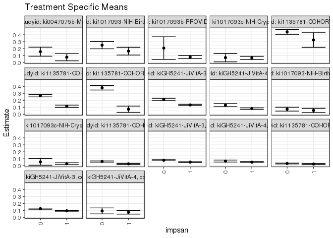

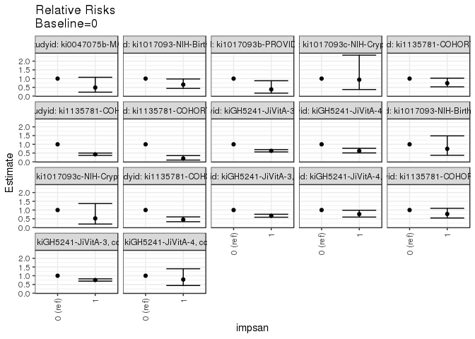

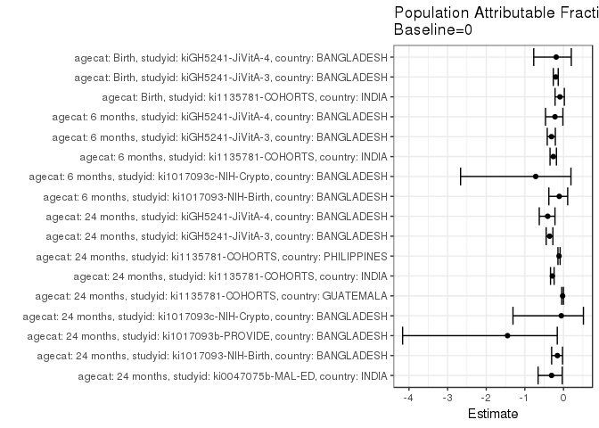

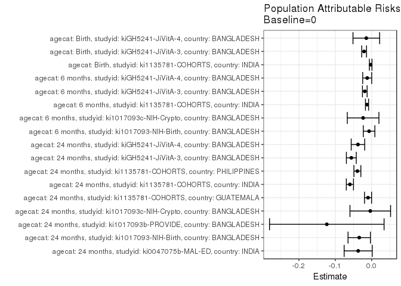

## Results Table

### Parameter: TSM

| agecat | studyid | country | intervention_level | baseline_level | estimate | ci_lower | ci_upper |
| --- | --- | --- | --- | --- | --- | --- | --- |
| Birth | ki1135781-COHORTS | INDIA | 0 | NA | 0.0322366 | 0.0259250 | 0.0385483 |
| Birth | ki1135781-COHORTS | INDIA | 1 | NA | 0.0249010 | 0.0176348 | 0.0321672 |
| Birth | kiGH5241-JiVitA-3 | BANGLADESH | 0 | NA | 0.1249024 | 0.1167821 | 0.1330227 |
| Birth | kiGH5241-JiVitA-3 | BANGLADESH | 1 | NA | 0.0941078 | 0.0885213 | 0.0996944 |
| Birth | kiGH5241-JiVitA-4 | BANGLADESH | 0 | NA | 0.0925926 | 0.0499058 | 0.1352793 |
| Birth | kiGH5241-JiVitA-4 | BANGLADESH | 1 | NA | 0.0726073 | 0.0470715 | 0.0981430 |
| 6 months | ki1017093-NIH-Birth | BANGLADESH | 0 | NA | 0.0722892 | 0.0444070 | 0.1001713 |
| 6 months | ki1017093-NIH-Birth | BANGLADESH | 1 | NA | 0.0536585 | 0.0227827 | 0.0845344 |
| 6 months | ki1017093c-NIH-Crypto | BANGLADESH | 0 | NA | 0.0561798 | 0.0083061 | 0.1040534 |
| 6 months | ki1017093c-NIH-Crypto | BANGLADESH | 1 | NA | 0.0292683 | 0.0159371 | 0.0425994 |
| 6 months | ki1135781-COHORTS | INDIA | 0 | NA | 0.0614887 | 0.0530178 | 0.0699596 |
| 6 months | ki1135781-COHORTS | INDIA | 1 | NA | 0.0276449 | 0.0202349 | 0.0350549 |
| 6 months | kiGH5241-JiVitA-3 | BANGLADESH | 0 | NA | 0.0795670 | 0.0715508 | 0.0875831 |
| 6 months | kiGH5241-JiVitA-3 | BANGLADESH | 1 | NA | 0.0531592 | 0.0489279 | 0.0573904 |
| 6 months | kiGH5241-JiVitA-4 | BANGLADESH | 0 | NA | 0.0679794 | 0.0538128 | 0.0821459 |
| 6 months | kiGH5241-JiVitA-4 | BANGLADESH | 1 | NA | 0.0521346 | 0.0443540 | 0.0599153 |
| 24 months | ki0047075b-MAL-ED | INDIA | 0 | NA | 0.1570248 | 0.0920546 | 0.2219950 |
| 24 months | ki0047075b-MAL-ED | INDIA | 1 | NA | 0.0769231 | 0.0255961 | 0.1282501 |
| 24 months | ki1017093-NIH-Birth | BANGLADESH | 0 | NA | 0.2509653 | 0.1981009 | 0.3038296 |
| 24 months | ki1017093-NIH-Birth | BANGLADESH | 1 | NA | 0.1647059 | 0.1088840 | 0.2205278 |
| 24 months | ki1017093b-PROVIDE | BANGLADESH | 0 | NA | 0.2083333 | 0.0457147 | 0.3709520 |
| 24 months | ki1017093b-PROVIDE | BANGLADESH | 1 | NA | 0.0797101 | 0.0570963 | 0.1023240 |
| 24 months | ki1017093c-NIH-Crypto | BANGLADESH | 0 | NA | 0.0714286 | 0.0110372 | 0.1318199 |
| 24 months | ki1017093c-NIH-Crypto | BANGLADESH | 1 | NA | 0.0669746 | 0.0434058 | 0.0905434 |
| 24 months | ki1135781-COHORTS | GUATEMALA | 0 | NA | 0.4407814 | 0.4067601 | 0.4748028 |
| 24 months | ki1135781-COHORTS | GUATEMALA | 1 | NA | 0.3246753 | 0.2200285 | 0.4293222 |
| 24 months | ki1135781-COHORTS | INDIA | 0 | NA | 0.2667543 | 0.2486103 | 0.2848983 |
| 24 months | ki1135781-COHORTS | INDIA | 1 | NA | 0.1142080 | 0.0979520 | 0.1304640 |
| 24 months | ki1135781-COHORTS | PHILIPPINES | 0 | NA | 0.3796296 | 0.3472541 | 0.4120051 |
| 24 months | ki1135781-COHORTS | PHILIPPINES | 1 | NA | 0.0714286 | 0.0264375 | 0.1164196 |
| 24 months | kiGH5241-JiVitA-3 | BANGLADESH | 0 | NA | 0.2116497 | 0.1946042 | 0.2286952 |
| 24 months | kiGH5241-JiVitA-3 | BANGLADESH | 1 | NA | 0.1327811 | 0.1232181 | 0.1423442 |
| 24 months | kiGH5241-JiVitA-4 | BANGLADESH | 0 | NA | 0.1297011 | 0.1081477 | 0.1512545 |
| 24 months | kiGH5241-JiVitA-4 | BANGLADESH | 1 | NA | 0.0811562 | 0.0707852 | 0.0915272 |

### Parameter: E(Y)

| agecat | studyid | country | intervention_level | baseline_level | estimate | ci_lower | ci_upper |
| --- | --- | --- | --- | --- | --- | --- | --- |
| Birth | ki1135781-COHORTS | INDIA | NA | NA | 0.0295226 | 0.0247216 | 0.0343236 |
| Birth | kiGH5241-JiVitA-3 | BANGLADESH | NA | NA | 0.1041752 | 0.0994998 | 0.1088506 |
| Birth | kiGH5241-JiVitA-4 | BANGLADESH | NA | NA | 0.0778589 | 0.0559066 | 0.0998111 |
| 6 months | ki1017093-NIH-Birth | BANGLADESH | NA | NA | 0.0651769 | 0.0442802 | 0.0860736 |
| 6 months | ki1017093c-NIH-Crypto | BANGLADESH | NA | NA | 0.0326705 | 0.0195292 | 0.0458117 |
| 6 months | ki1135781-COHORTS | INDIA | NA | NA | 0.0486824 | 0.0426994 | 0.0546654 |
| 6 months | kiGH5241-JiVitA-3 | BANGLADESH | NA | NA | 0.0606467 | 0.0567903 | 0.0645031 |
| 6 months | kiGH5241-JiVitA-4 | BANGLADESH | NA | NA | 0.0557144 | 0.0488132 | 0.0626157 |
| 24 months | ki0047075b-MAL-ED | INDIA | NA | NA | 0.1200000 | 0.0774445 | 0.1625555 |
| 24 months | ki1017093-NIH-Birth | BANGLADESH | NA | NA | 0.2167832 | 0.1777459 | 0.2558205 |
| 24 months | ki1017093b-PROVIDE | BANGLADESH | NA | NA | 0.0850694 | 0.0622663 | 0.1078726 |
| 24 months | ki1017093c-NIH-Crypto | BANGLADESH | NA | NA | 0.0675944 | 0.0456333 | 0.0895555 |
| 24 months | ki1135781-COHORTS | GUATEMALA | NA | NA | 0.4308036 | 0.3983616 | 0.4632455 |
| 24 months | ki1135781-COHORTS | INDIA | NA | NA | 0.2069792 | 0.1940174 | 0.2199410 |
| 24 months | ki1135781-COHORTS | PHILIPPINES | NA | NA | 0.3404040 | 0.3108725 | 0.3699356 |
| 24 months | kiGH5241-JiVitA-3 | BANGLADESH | NA | NA | 0.1557596 | 0.1470134 | 0.1645058 |
| 24 months | kiGH5241-JiVitA-4 | BANGLADESH | NA | NA | 0.0920173 | 0.0825478 | 0.1014867 |

### Parameter: RR

| agecat | studyid | country | intervention_level | baseline_level | estimate | ci_lower | ci_upper |
| --- | --- | --- | --- | --- | --- | --- | --- |
| Birth | ki1135781-COHORTS | INDIA | 0 | 0 | 1.0000000 | 1.0000000 | 1.0000000 |
| Birth | ki1135781-COHORTS | INDIA | 1 | 0 | 0.7724432 | 0.5435686 | 1.0976876 |
| Birth | kiGH5241-JiVitA-3 | BANGLADESH | 0 | 0 | 1.0000000 | 1.0000000 | 1.0000000 |
| Birth | kiGH5241-JiVitA-3 | BANGLADESH | 1 | 0 | 0.7534508 | 0.6907097 | 0.8218911 |
| Birth | kiGH5241-JiVitA-4 | BANGLADESH | 0 | 0 | 1.0000000 | 1.0000000 | 1.0000000 |
| Birth | kiGH5241-JiVitA-4 | BANGLADESH | 1 | 0 | 0.7841584 | 0.4397029 | 1.3984542 |
| 6 months | ki1017093-NIH-Birth | BANGLADESH | 0 | 0 | 1.0000000 | 1.0000000 | 1.0000000 |
| 6 months | ki1017093-NIH-Birth | BANGLADESH | 1 | 0 | 0.7422764 | 0.3712948 | 1.4839268 |
| 6 months | ki1017093c-NIH-Crypto | BANGLADESH | 0 | 0 | 1.0000000 | 1.0000000 | 1.0000000 |
| 6 months | ki1017093c-NIH-Crypto | BANGLADESH | 1 | 0 | 0.5209756 | 0.1982366 | 1.3691498 |
| 6 months | ki1135781-COHORTS | INDIA | 0 | 0 | 1.0000000 | 1.0000000 | 1.0000000 |
| 6 months | ki1135781-COHORTS | INDIA | 1 | 0 | 0.4495929 | 0.3326099 | 0.6077203 |
| 6 months | kiGH5241-JiVitA-3 | BANGLADESH | 0 | 0 | 1.0000000 | 1.0000000 | 1.0000000 |
| 6 months | kiGH5241-JiVitA-3 | BANGLADESH | 1 | 0 | 0.6681063 | 0.5884451 | 0.7585518 |
| 6 months | kiGH5241-JiVitA-4 | BANGLADESH | 0 | 0 | 1.0000000 | 1.0000000 | 1.0000000 |
| 6 months | kiGH5241-JiVitA-4 | BANGLADESH | 1 | 0 | 0.7669186 | 0.5956621 | 0.9874125 |
| 24 months | ki0047075b-MAL-ED | INDIA | 0 | 0 | 1.0000000 | 1.0000000 | 1.0000000 |
| 24 months | ki0047075b-MAL-ED | INDIA | 1 | 0 | 0.4898785 | 0.2234156 | 1.0741461 |
| 24 months | ki1017093-NIH-Birth | BANGLADESH | 0 | 0 | 1.0000000 | 1.0000000 | 1.0000000 |
| 24 months | ki1017093-NIH-Birth | BANGLADESH | 1 | 0 | 0.6562896 | 0.4403445 | 0.9781343 |
| 24 months | ki1017093b-PROVIDE | BANGLADESH | 0 | 0 | 1.0000000 | 1.0000000 | 1.0000000 |
| 24 months | ki1017093b-PROVIDE | BANGLADESH | 1 | 0 | 0.3826087 | 0.1667483 | 0.8779063 |
| 24 months | ki1017093c-NIH-Crypto | BANGLADESH | 0 | 0 | 1.0000000 | 1.0000000 | 1.0000000 |
| 24 months | ki1017093c-NIH-Crypto | BANGLADESH | 1 | 0 | 0.9376443 | 0.3752451 | 2.3429402 |
| 24 months | ki1135781-COHORTS | GUATEMALA | 0 | 0 | 1.0000000 | 1.0000000 | 1.0000000 |
| 24 months | ki1135781-COHORTS | GUATEMALA | 1 | 0 | 0.7365903 | 0.5287981 | 1.0260348 |
| 24 months | ki1135781-COHORTS | INDIA | 0 | 0 | 1.0000000 | 1.0000000 | 1.0000000 |
| 24 months | ki1135781-COHORTS | INDIA | 1 | 0 | 0.4281394 | 0.3656569 | 0.5012989 |
| 24 months | ki1135781-COHORTS | PHILIPPINES | 0 | 0 | 1.0000000 | 1.0000000 | 1.0000000 |
| 24 months | ki1135781-COHORTS | PHILIPPINES | 1 | 0 | 0.1881533 | 0.0996472 | 0.3552702 |
| 24 months | kiGH5241-JiVitA-3 | BANGLADESH | 0 | 0 | 1.0000000 | 1.0000000 | 1.0000000 |
| 24 months | kiGH5241-JiVitA-3 | BANGLADESH | 1 | 0 | 0.6273626 | 0.5646181 | 0.6970797 |
| 24 months | kiGH5241-JiVitA-4 | BANGLADESH | 0 | 0 | 1.0000000 | 1.0000000 | 1.0000000 |
| 24 months | kiGH5241-JiVitA-4 | BANGLADESH | 1 | 0 | 0.6257173 | 0.5075475 | 0.7714000 |

### Parameter: PAR

| agecat | studyid | country | intervention_level | baseline_level | estimate | ci_lower | ci_upper |
| --- | --- | --- | --- | --- | --- | --- | --- |
| Birth | ki1135781-COHORTS | INDIA | 0 | NA | -0.0027140 | -0.0062763 | 0.0008483 |
| Birth | kiGH5241-JiVitA-3 | BANGLADESH | 0 | NA | -0.0207272 | -0.0273004 | -0.0141541 |
| Birth | kiGH5241-JiVitA-4 | BANGLADESH | 0 | NA | -0.0147337 | -0.0513459 | 0.0218785 |
| 6 months | ki1017093-NIH-Birth | BANGLADESH | 0 | NA | -0.0071122 | -0.0230123 | 0.0087878 |
| 6 months | ki1017093c-NIH-Crypto | BANGLADESH | 0 | NA | -0.0235093 | -0.0669270 | 0.0199083 |
| 6 months | ki1135781-COHORTS | INDIA | 0 | NA | -0.0128063 | -0.0170893 | -0.0085233 |
| 6 months | kiGH5241-JiVitA-3 | BANGLADESH | 0 | NA | -0.0189203 | -0.0253595 | -0.0124810 |
| 6 months | kiGH5241-JiVitA-4 | BANGLADESH | 0 | NA | -0.0122649 | -0.0246387 | 0.0001088 |
| 24 months | ki0047075b-MAL-ED | INDIA | 0 | NA | -0.0370248 | -0.0756518 | 0.0016022 |
| 24 months | ki1017093-NIH-Birth | BANGLADESH | 0 | NA | -0.0341820 | -0.0649089 | -0.0034552 |
| 24 months | ki1017093b-PROVIDE | BANGLADESH | 0 | NA | -0.1232639 | -0.2806204 | 0.0340926 |
| 24 months | ki1017093c-NIH-Crypto | BANGLADESH | 0 | NA | -0.0038341 | -0.0596401 | 0.0519718 |
| 24 months | ki1135781-COHORTS | GUATEMALA | 0 | NA | -0.0099779 | -0.0196716 | -0.0002841 |
| 24 months | ki1135781-COHORTS | INDIA | 0 | NA | -0.0597750 | -0.0696137 | -0.0499364 |
| 24 months | ki1135781-COHORTS | PHILIPPINES | 0 | NA | -0.0392256 | -0.0487518 | -0.0296994 |
| 24 months | kiGH5241-JiVitA-3 | BANGLADESH | 0 | NA | -0.0558901 | -0.0694714 | -0.0423088 |
| 24 months | kiGH5241-JiVitA-4 | BANGLADESH | 0 | NA | -0.0376838 | -0.0562513 | -0.0191163 |

### Parameter: PAF

| agecat | studyid | country | intervention_level | baseline_level | estimate | ci_lower | ci_upper |
| --- | --- | --- | --- | --- | --- | --- | --- |
| Birth | ki1135781-COHORTS | INDIA | 0 | NA | -0.0919299 | -0.2185443 | 0.0215285 |
| Birth | kiGH5241-JiVitA-3 | BANGLADESH | 0 | NA | -0.1989653 | -0.2642824 | -0.1370227 |
| Birth | kiGH5241-JiVitA-4 | BANGLADESH | 0 | NA | -0.1892361 | -0.7705068 | 0.2011991 |
| 6 months | ki1017093-NIH-Birth | BANGLADESH | 0 | NA | -0.1091222 | -0.3793326 | 0.1081542 |
| 6 months | ki1017093c-NIH-Crypto | BANGLADESH | 0 | NA | -0.7195896 | -2.6639645 | 0.1929538 |
| 6 months | ki1135781-COHORTS | INDIA | 0 | NA | -0.2630587 | -0.3484676 | -0.1830593 |
| 6 months | kiGH5241-JiVitA-3 | BANGLADESH | 0 | NA | -0.3119750 | -0.4211352 | -0.2111996 |
| 6 months | kiGH5241-JiVitA-4 | BANGLADESH | 0 | NA | -0.2201393 | -0.4657393 | -0.0156921 |
| 24 months | ki0047075b-MAL-ED | INDIA | 0 | NA | -0.3085399 | -0.6579610 | -0.0327606 |
| 24 months | ki1017093-NIH-Birth | BANGLADESH | 0 | NA | -0.1576784 | -0.3073025 | -0.0251792 |
| 24 months | ki1017093b-PROVIDE | BANGLADESH | 0 | NA | -1.4489796 | -4.1647651 | -0.1612340 |
| 24 months | ki1017093c-NIH-Crypto | BANGLADESH | 0 | NA | -0.0567227 | -1.3077912 | 0.5161335 |
| 24 months | ki1135781-COHORTS | GUATEMALA | 0 | NA | -0.0231611 | -0.0459498 | -0.0008689 |
| 24 months | ki1135781-COHORTS | INDIA | 0 | NA | -0.2887973 | -0.3360376 | -0.2432274 |
| 24 months | ki1135781-COHORTS | PHILIPPINES | 0 | NA | -0.1152324 | -0.1438468 | -0.0873339 |
| 24 months | kiGH5241-JiVitA-3 | BANGLADESH | 0 | NA | -0.3588227 | -0.4486806 | -0.2745385 |
| 24 months | kiGH5241-JiVitA-4 | BANGLADESH | 0 | NA | -0.4095297 | -0.6273814 | -0.2208410 |